# Data Wrangling with tidyverse

Kyla McConnell

6/13/2019

# Data Wrangling with tidyverse

These notes and excercises come directly from [Chapter 5 of R for Data Science](https://r4ds.had.co.nz/transform.html) & [12](https://r4ds.had.co.nz/tidy-data.html) & Lisa DeBruine & Dale Barr’s Data Skills [Part 5](https://gupsych.github.io/data_skills/05_wrangling.html). These notes are meant to accompany, not replace, these great resources!

## Setup

```r
library(tidyverse)
library(nycflights13) #for flights data

flights <- flights #from the nycflights13 package
```

# Data transformation

Note that many of these changes would have to be saved back to the original dataframe to take permanent effect and are just shown here as temporary outputs.

Ex to save permanently: `flights <- flights %>%` `filter(month == 1, day == 1)`

## filter()

`filter()`returns the values that match your criteria.

You can use the logical operators >, >=, <, <=, !=, ==

You can combine logical operators with `&`, `|` and `!` (*and*, *or*, and *not*) Note: !(x & y) is the same as !x | !y, and !(x | y) is the same as !x & !y

If you are using a value with a lot of decimals, use `near()` to allow R to approximate the number i.e. `col1 == near(sqrt(2) ^ 2, 2))`

Arguments: 1. column1 (logical operator) outcome to match 2. opt: column 2 (logical operator) outcome to match

[output not shown]

```r
flights %>%
  filter(month == 1, day == 1) #returns all flights on January 1st
```

| year | month | day | dep_time | sched_dep_time | dep_delay | arr_time | sched_arr_time | arr_delay | carrier | flight | tailnum | origin | dest | air_time | distance | hour | minute | time_hour |
| --- | --- | --- | --- | --- | --- | --- | --- | --- | --- | --- | --- | --- | --- | --- | --- | --- | --- | --- |
| 2013 | 1 | 1 | 517 | 515 | 2 | 830 | 819 | 11 | UA | 1545 | N14228 | EWR | IAH | 227 | 1400 | 5 | 15 | 2013-01-01 05:00:00 |
| 2013 | 1 | 1 | 533 | 529 | 4 | 850 | 830 | 20 | UA | 1714 | N24211 | LGA | IAH | 227 | 1416 | 5 | 29 | 2013-01-01 05:00:00 |
| 2013 | 1 | 1 | 542 | 540 | 2 | 923 | 850 | 33 | AA | 1141 | N619AA | JFK | MIA | 160 | 1089 | 5 | 40 | 2013-01-01 05:00:00 |
| 2013 | 1 | 1 | 544 | 545 | -1 | 1004 | 1022 | -18 | B6 | 725 | N804JB | JFK | BQN | 183 | 1576 | 5 | 45 | 2013-01-01 05:00:00 |
| 2013 | 1 | 1 | 554 | 600 | -6 | 812 | 837 | -25 | DL | 461 | N668DN | LGA | ATL | 116 | 762 | 6 | 0 | 2013-01-01 06:00:00 |
| 2013 | 1 | 1 | 554 | 558 | -4 | 740 | 728 | 12 | UA | 1696 | N39463 | EWR | ORD | 150 | 719 | 5 | 58 | 2013-01-01 05:00:00 |
| 2013 | 1 | 1 | 555 | 600 | -5 | 913 | 854 | 19 | B6 | 507 | N516JB | EWR | FLL | 158 | 1065 | 6 | 0 | 2013-01-01 06:00:00 |
| 2013 | 1 | 1 | 557 | 600 | -3 | 709 | 723 | -14 | EV | 5708 | N829AS | LGA | IAD | 53 | 229 | 6 | 0 | 2013-01-01 06:00:00 |
| 2013 | 1 | 1 | 557 | 600 | -3 | 838 | 846 | -8 | B6 | 79 | N593JB | JFK | MCO | 140 | 944 | 6 | 0 | 2013-01-01 06:00:00 |
| 2013 | 1 | 1 | 558 | 600 | -2 | 753 | 745 | 8 | AA | 301 | N3ALAA | LGA | ORD | 138 | 733 | 6 | 0 | 2013-01-01 06:00:00 |

[output cut: 832 more lines]

```r
filter(flights, month == 11 | month == 12) #returns all flights in November or December
```

| year | month | day | dep_time | sched_dep_time | dep_delay | arr_time | sched_arr_time | arr_delay | carrier | flight | tailnum | origin | dest | air_time | distance | hour | minute | time_hour |
| --- | --- | --- | --- | --- | --- | --- | --- | --- | --- | --- | --- | --- | --- | --- | --- | --- | --- | --- |
| 2013 | 11 | 1 | 5 | 2359 | 6 | 352 | 345 | 7 | B6 | 745 | N568JB | JFK | PSE | 205 | 1617 | 23 | 59 | 2013-11-01 23:00:00 |
| 2013 | 11 | 1 | 35 | 2250 | 105 | 123 | 2356 | 87 | B6 | 1816 | N353JB | JFK | SYR | 36 | 209 | 22 | 50 | 2013-11-01 22:00:00 |
| 2013 | 11 | 1 | 455 | 500 | -5 | 641 | 651 | -10 | US | 1895 | N192UW | EWR | CLT | 88 | 529 | 5 | 0 | 2013-11-01 05:00:00 |
| 2013 | 11 | 1 | 539 | 545 | -6 | 856 | 827 | 29 | UA | 1714 | N38727 | LGA | IAH | 229 | 1416 | 5 | 45 | 2013-11-01 05:00:00 |
| 2013 | 11 | 1 | 542 | 545 | -3 | 831 | 855 | -24 | AA | 2243 | N5CLAA | JFK | MIA | 147 | 1089 | 5 | 45 | 2013-11-01 05:00:00 |
| 2013 | 11 | 1 | 549 | 600 | -11 | 912 | 923 | -11 | UA | 303 | N595UA | JFK | SFO | 359 | 2586 | 6 | 0 | 2013-11-01 06:00:00 |
| 2013 | 11 | 1 | 550 | 600 | -10 | 705 | 659 | 6 | US | 2167 | N748UW | LGA | DCA | 57 | 214 | 6 | 0 | 2013-11-01 06:00:00 |
| 2013 | 11 | 1 | 554 | 600 | -6 | 659 | 701 | -2 | US | 2134 | N742PS | LGA | BOS | 40 | 184 | 6 | 0 | 2013-11-01 06:00:00 |
| 2013 | 11 | 1 | 554 | 600 | -6 | 826 | 827 | -1 | DL | 563 | N912DE | LGA | ATL | 126 | 762 | 6 | 0 | 2013-11-01 06:00:00 |
| 2013 | 11 | 1 | 554 | 600 | -6 | 749 | 751 | -2 | DL | 731 | N315NB | LGA | DTW | 93 | 502 | 6 | 0 | 2013-11-01 06:00:00 |

[output cut: 990 more lines]

```r
flights %>%
  filter(arr_delay >= 120 & dep_delay == 0) #returns all flights with an arival delay of greater than or equal to 120min and  departure delay of 0
```

| year | month | day | dep_time | sched_dep_time | dep_delay | arr_time | sched_arr_time | arr_delay | carrier | flight | tailnum | origin | dest | air_time | distance | hour | minute | time_hour |
| --- | --- | --- | --- | --- | --- | --- | --- | --- | --- | --- | --- | --- | --- | --- | --- | --- | --- | --- |
| 2013 | 10 | 7 | 1350 | 1350 | 0 | 1736 | 1526 | 130 | EV | 5181 | N611QX | LGA | MSN | 117 | 812 | 13 | 50 | 2013-10-07 13:00:00 |
| 2013 | 5 | 23 | 1810 | 1810 | 0 | 2208 | 2000 | 128 | MQ | 4626 | N525MQ | LGA | CMH | 82 | 479 | 18 | 10 | 2013-05-23 18:00:00 |
| 2013 | 7 | 1 | 905 | 905 | 0 | 1443 | 1223 | 140 | DL | 1057 | N337NB | LGA | MIA | 183 | 1096 | 9 | 5 | 2013-07-01 09:00:00 |

Another option is `%in%`, which selects every row where x is one of the values of y.

| year | month | day | dep_time | sched_dep_time | dep_delay | arr_time | sched_arr_time | arr_delay | carrier | flight | tailnum | origin | dest | air_time | distance | hour | minute | time_hour |
| --- | --- | --- | --- | --- | --- | --- | --- | --- | --- | --- | --- | --- | --- | --- | --- | --- | --- | --- |
| 2013 | 11 | 1 | 5 | 2359 | 6 | 352 | 345 | 7 | B6 | 745 | N568JB | JFK | PSE | 205 | 1617 | 23 | 59 | 2013-11-01 23:00:00 |
| 2013 | 11 | 1 | 35 | 2250 | 105 | 123 | 2356 | 87 | B6 | 1816 | N353JB | JFK | SYR | 36 | 209 | 22 | 50 | 2013-11-01 22:00:00 |
| 2013 | 11 | 1 | 455 | 500 | -5 | 641 | 651 | -10 | US | 1895 | N192UW | EWR | CLT | 88 | 529 | 5 | 0 | 2013-11-01 05:00:00 |
| 2013 | 11 | 1 | 539 | 545 | -6 | 856 | 827 | 29 | UA | 1714 | N38727 | LGA | IAH | 229 | 1416 | 5 | 45 | 2013-11-01 05:00:00 |
| 2013 | 11 | 1 | 542 | 545 | -3 | 831 | 855 | -24 | AA | 2243 | N5CLAA | JFK | MIA | 147 | 1089 | 5 | 45 | 2013-11-01 05:00:00 |
| 2013 | 11 | 1 | 549 | 600 | -11 | 912 | 923 | -11 | UA | 303 | N595UA | JFK | SFO | 359 | 2586 | 6 | 0 | 2013-11-01 06:00:00 |

`filter()` can also be used to show NAs in combination with the is.na() function.

```r
flights %>%
  filter(is.na(dep_time)) %>%
  head()
```

| year | month | day | dep_time | sched_dep_time | dep_delay | arr_time | sched_arr_time | arr_delay | carrier | flight | tailnum | origin | dest | air_time | distance | hour | minute | time_hour |
| --- | --- | --- | --- | --- | --- | --- | --- | --- | --- | --- | --- | --- | --- | --- | --- | --- | --- | --- |
| 2013 | 1 | 1 | NA | 1630 | NA | NA | 1815 | NA | EV | 4308 | N18120 | EWR | RDU | NA | 416 | 16 | 30 | 2013-01-01 16:00:00 |
| 2013 | 1 | 1 | NA | 1935 | NA | NA | 2240 | NA | AA | 791 | N3EHAA | LGA | DFW | NA | 1389 | 19 | 35 | 2013-01-01 19:00:00 |
| 2013 | 1 | 1 | NA | 1500 | NA | NA | 1825 | NA | AA | 1925 | N3EVAA | LGA | MIA | NA | 1096 | 15 | 0 | 2013-01-01 15:00:00 |
| 2013 | 1 | 1 | NA | 600 | NA | NA | 901 | NA | B6 | 125 | N618JB | JFK | FLL | NA | 1069 | 6 | 0 | 2013-01-01 06:00:00 |
| 2013 | 1 | 2 | NA | 1540 | NA | NA | 1747 | NA | EV | 4352 | N10575 | EWR | CVG | NA | 569 | 15 | 40 | 2013-01-02 15:00:00 |
| 2013 | 1 | 2 | NA | 1620 | NA | NA | 1746 | NA | EV | 4406 | N13949 | EWR | PIT | NA | 319 | 16 | 20 | 2013-01-02 16:00:00 |

### between()

A useful filtering helper is between(). It is a shortcut for for x >= left & x <= right.

Syntax: between(x, left, right)

Example: `ukb %>% filter(sex == "M", name == "Courtney", between(year, 1998, 2001))`

## arrange()

`arrange()` orders the values of the columns. If you give more than one column, the following column will be the tiebreaker for preceding columns.

Use desc(COLUMNNAME) to arrange in descending order

```r
arrange(flights, year, month, day) %>%
  head()
```

| year | month | day | dep_time | sched_dep_time | dep_delay | arr_time | sched_arr_time | arr_delay | carrier | flight | tailnum | origin | dest | air_time | distance | hour | minute | time_hour |
| --- | --- | --- | --- | --- | --- | --- | --- | --- | --- | --- | --- | --- | --- | --- | --- | --- | --- | --- |
| 2013 | 1 | 1 | 517 | 515 | 2 | 830 | 819 | 11 | UA | 1545 | N14228 | EWR | IAH | 227 | 1400 | 5 | 15 | 2013-01-01 05:00:00 |
| 2013 | 1 | 1 | 533 | 529 | 4 | 850 | 830 | 20 | UA | 1714 | N24211 | LGA | IAH | 227 | 1416 | 5 | 29 | 2013-01-01 05:00:00 |
| 2013 | 1 | 1 | 542 | 540 | 2 | 923 | 850 | 33 | AA | 1141 | N619AA | JFK | MIA | 160 | 1089 | 5 | 40 | 2013-01-01 05:00:00 |
| 2013 | 1 | 1 | 544 | 545 | -1 | 1004 | 1022 | -18 | B6 | 725 | N804JB | JFK | BQN | 183 | 1576 | 5 | 45 | 2013-01-01 05:00:00 |
| 2013 | 1 | 1 | 554 | 600 | -6 | 812 | 837 | -25 | DL | 461 | N668DN | LGA | ATL | 116 | 762 | 6 | 0 | 2013-01-01 06:00:00 |
| 2013 | 1 | 1 | 554 | 558 | -4 | 740 | 728 | 12 | UA | 1696 | N39463 | EWR | ORD | 150 | 719 | 5 | 58 | 2013-01-01 05:00:00 |

Note: NAs go at the end by default.

## select()

`select()` gives you the table with the columns you provide, in that order. It will only return the selected columns and can be used to subset several columns.

You can use multiple functions with `select()` `starts_with("")` `ends_with("")` `contains("")` `matches("")`(takes regular expressions) `num_range("x", 1:3)` (matches x1, x2, x3) `one_of()` “matches variable names in a character vector”

```r
flights %>%
  select(year, month, day)
```

| year | month | day |
| --- | --- | --- |
| 2013 | 1 | 1 |
| 2013 | 1 | 1 |
| 2013 | 1 | 1 |
| 2013 | 1 | 1 |
| 2013 | 1 | 1 |
| 2013 | 1 | 1 |
| 2013 | 1 | 1 |
| 2013 | 1 | 1 |
| 2013 | 1 | 1 |
| 2013 | 1 | 1 |

[output cut: 990 more lines]

You can also select or deselect a range of columns with a colon (:). You can also remove columns by preceding them with minus (-).

```r
select(flights, -(year:day)) %>%
  head()
```

| dep_time | sched_dep_time | dep_delay | arr_time | sched_arr_time | arr_delay | carrier | flight | tailnum | origin | dest | air_time | distance | hour | minute | time_hour |
| --- | --- | --- | --- | --- | --- | --- | --- | --- | --- | --- | --- | --- | --- | --- | --- |
| 517 | 515 | 2 | 830 | 819 | 11 | UA | 1545 | N14228 | EWR | IAH | 227 | 1400 | 5 | 15 | 2013-01-01 05:00:00 |
| 533 | 529 | 4 | 850 | 830 | 20 | UA | 1714 | N24211 | LGA | IAH | 227 | 1416 | 5 | 29 | 2013-01-01 05:00:00 |
| 542 | 540 | 2 | 923 | 850 | 33 | AA | 1141 | N619AA | JFK | MIA | 160 | 1089 | 5 | 40 | 2013-01-01 05:00:00 |
| 544 | 545 | -1 | 1004 | 1022 | -18 | B6 | 725 | N804JB | JFK | BQN | 183 | 1576 | 5 | 45 | 2013-01-01 05:00:00 |
| 554 | 600 | -6 | 812 | 837 | -25 | DL | 461 | N668DN | LGA | ATL | 116 | 762 | 6 | 0 | 2013-01-01 06:00:00 |
| 554 | 558 | -4 | 740 | 728 | 12 | UA | 1696 | N39463 | EWR | ORD | 150 | 719 | 5 | 58 | 2013-01-01 05:00:00 |

`select()` will only return the columns you explicitly list, unless you use `everything()` Using this can be useful just for reordering columns without excluding anything.

```r
select(flights, time_hour, air_time, everything()) %>%
  head()
```

| time_hour | air_time | year | month | day | dep_time | sched_dep_time | dep_delay | arr_time | sched_arr_time | arr_delay | carrier | flight | tailnum | origin | dest | distance | hour | minute |
| --- | --- | --- | --- | --- | --- | --- | --- | --- | --- | --- | --- | --- | --- | --- | --- | --- | --- | --- |
| 2013-01-01 05:00:00 | 227 | 2013 | 1 | 1 | 517 | 515 | 2 | 830 | 819 | 11 | UA | 1545 | N14228 | EWR | IAH | 1400 | 5 | 15 |
| 2013-01-01 05:00:00 | 227 | 2013 | 1 | 1 | 533 | 529 | 4 | 850 | 830 | 20 | UA | 1714 | N24211 | LGA | IAH | 1416 | 5 | 29 |
| 2013-01-01 05:00:00 | 160 | 2013 | 1 | 1 | 542 | 540 | 2 | 923 | 850 | 33 | AA | 1141 | N619AA | JFK | MIA | 1089 | 5 | 40 |
| 2013-01-01 05:00:00 | 183 | 2013 | 1 | 1 | 544 | 545 | -1 | 1004 | 1022 | -18 | B6 | 725 | N804JB | JFK | BQN | 1576 | 5 | 45 |
| 2013-01-01 06:00:00 | 116 | 2013 | 1 | 1 | 554 | 600 | -6 | 812 | 837 | -25 | DL | 461 | N668DN | LGA | ATL | 762 | 6 | 0 |
| 2013-01-01 05:00:00 | 150 | 2013 | 1 | 1 | 554 | 558 | -4 | 740 | 728 | 12 | UA | 1696 | N39463 | EWR | ORD | 719 | 5 | 58 |

## rename()

Renames columns. Ex: `rename(flights, tail_num = tailnum)` renames the column ‘tailnum’ to ‘tail_num’.

## mutate()

You can use: -arithmetic operators: `+`, `-`, `*`, `x/sum(x)` (proportion), `x - mean(x)` (diff. from mean), `%/%` (integer rounding), `%%` (modulo), `log2()`, etc. -logical comparisons: `==`, `!=`, `<=`, etc. -other: `min_rank`, `max_rank`, `cumsum`, `cummean`, `ntile`, `row_number()`

| year | month | day | dep_time | sched_dep_time | dep_delay | arr_time | sched_arr_time | arr_delay | carrier | flight | tailnum | origin | dest | air_time | distance | hour | minute | time_hour | gain | hours | gain_per_hour |
| --- | --- | --- | --- | --- | --- | --- | --- | --- | --- | --- | --- | --- | --- | --- | --- | --- | --- | --- | --- | --- | --- |
| 2013 | 1 | 1 | 517 | 515 | 2 | 830 | 819 | 11 | UA | 1545 | N14228 | EWR | IAH | 227 | 1400 | 5 | 15 | 2013-01-01 05:00:00 | -9 | 3.783333 | -2.378855 |
| 2013 | 1 | 1 | 533 | 529 | 4 | 850 | 830 | 20 | UA | 1714 | N24211 | LGA | IAH | 227 | 1416 | 5 | 29 | 2013-01-01 05:00:00 | -16 | 3.783333 | -4.229075 |
| 2013 | 1 | 1 | 542 | 540 | 2 | 923 | 850 | 33 | AA | 1141 | N619AA | JFK | MIA | 160 | 1089 | 5 | 40 | 2013-01-01 05:00:00 | -31 | 2.666667 | -11.625000 |
| 2013 | 1 | 1 | 544 | 545 | -1 | 1004 | 1022 | -18 | B6 | 725 | N804JB | JFK | BQN | 183 | 1576 | 5 | 45 | 2013-01-01 05:00:00 | 17 | 3.050000 | 5.573770 |
| 2013 | 1 | 1 | 554 | 600 | -6 | 812 | 837 | -25 | DL | 461 | N668DN | LGA | ATL | 116 | 762 | 6 | 0 | 2013-01-01 06:00:00 | 19 | 1.933333 | 9.827586 |
| 2013 | 1 | 1 | 554 | 558 | -4 | 740 | 728 | 12 | UA | 1696 | N39463 | EWR | ORD | 150 | 719 | 5 | 58 | 2013-01-01 05:00:00 | -16 | 2.500000 | -6.400000 |

### transmute()

`transmute()` is similiar to mutate but keeps only the new columns you create and deletes the others.

```r
flights %>%
  transmute(
    dep_time,
    hour = dep_time %/% 100,
    minute = dep_time %% 100
    ) %>%
  head()
```

| dep_time | hour | minute |
| --- | --- | --- |
| 517 | 5 | 17 |
| 533 | 5 | 33 |
| 542 | 5 | 42 |
| 544 | 5 | 44 |
| 554 | 5 | 54 |
| 554 | 5 | 54 |

## summarise() and group_by()

`summarise()` collaspes a dataframe into a single row. It is most useful when used with `group_by()`, which allows you to look at different groups.

Some things you can summarise include: -`mean()`, `median()`, `sd()` -`min()`, `max()` -`x[length(x)]` (last in the range) -`IQR()` interquartile range -`quantile(x, 0.25)` will find a value of the 25th quantile -Measures of position: `first(x)`, `nth(x, 2)`, `last(x)` -Count: `n()` -Count NAs: `sum(!is.na(x))` -Count uniques: `n_distinct(x)`

```r
flights %>%
  group_by(year, month, day) %>%
  summarise(delay = mean(dep_delay, na.rm = TRUE)) %>%
  head()
```

| year | month | day | delay |
| --- | --- | --- | --- |
| 2013 | 1 | 1 | 11.548926 |
| 2013 | 1 | 2 | 13.858824 |
| 2013 | 1 | 3 | 10.987832 |
| 2013 | 1 | 4 | 8.951595 |
| 2013 | 1 | 5 | 5.732218 |
| 2013 | 1 | 6 | 7.148014 |

Note that `na.rm = TRUE` is really important here, or else the mean for any group with any NA in the column dep_delay would be NA!

When you use `groupby()`, it’s helpful to include the count `n()` to get an idea for the scale that you’re looking at. For example, to know if you’re looking at a mean of 4 datapoints or 4000.

| tailnum | delay | n |
| --- | --- | --- |
| D942DN | 31.500000 | 4 |
| N0EGMQ | 9.982955 | 352 |
| N10156 | 12.717241 | 145 |
| N102UW | 2.937500 | 48 |
| N103US | -6.934783 | 46 |
| N104UW | 1.804348 | 46 |

Note that we first removed NAs systematically to better work with the data.

Another example, here we summarize the average sandard deviation by destination arranged in descending order.

| dest | distance_sd |
| --- | --- |
| EGE | 10.542765 |
| SAN | 10.350094 |
| SFO | 10.216017 |
| HNL | 10.004197 |
| SEA | 9.977993 |
| LAS | 9.907786 |

Here, we find the destinations with the most carriers:

```r
not_cancelled %>%
  group_by(dest) %>%
  summarise(carriers = n_distinct(carrier)) %>%
  arrange(desc(carriers)) %>%
  head()
```

| dest | carriers |
| --- | --- |
| ATL | 7 |
| BOS | 7 |
| CLT | 7 |
| ORD | 7 |
| TPA | 7 |
| AUS | 6 |

You can also use logical operators with `summarise()`, because TRUE returns 1 and FALSE returns 0.

```r
not_cancelled %>%
  group_by(year, month, day) %>%
  summarise(n_early = sum(dep_time < 500)) %>%
  head()
```

| year | month | day | n_early |
| --- | --- | --- | --- |
| 2013 | 1 | 1 | 0 |
| 2013 | 1 | 2 | 3 |
| 2013 | 1 | 3 | 4 |
| 2013 | 1 | 4 | 3 |
| 2013 | 1 | 5 | 3 |
| 2013 | 1 | 6 | 2 |

### count()

Returns a count of all unique options.

| dest | n |
| --- | --- |
| ABQ | 254 |
| ACK | 264 |
| ALB | 418 |
| ANC | 8 |
| ATL | 16837 |
| AUS | 2411 |

You can also use it to sum another variable by providing a ‘weight’ `wt=`

```r
not_cancelled %>%
  count(tailnum, wt = distance) %>%
  head()
```

| tailnum | n |
| --- | --- |
| D942DN | 3418 |
| N0EGMQ | 239143 |
| N10156 | 109664 |
| N102UW | 25722 |
| N103US | 24619 |
| N104UW | 24616 |

## ungroup()

To undo the grouping use `ungroup()`. This is useful when you want to create a new column by calculating a group variable, then want to return to original rows for further steps.

## ggplot

You can also include ggplot in dplyr piped sequences to take a look at data. Just note that ggplot doesn’t use pipes but rather +

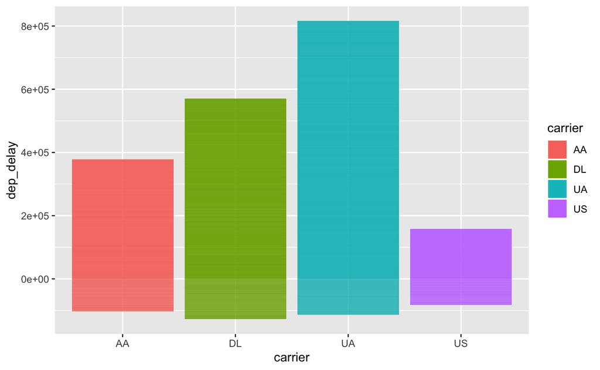

```r
flights %>%
  filter(carrier %in% c("AA", "DL", "UA", "US")) %>%
  ggplot(mapping = aes(x = carrier, y = dep_delay, fill = carrier)) +
    geom_bar(stat="identity")
```